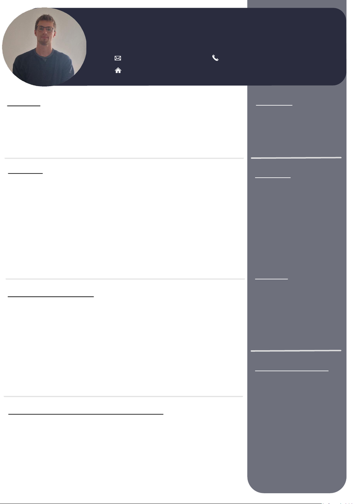

Nicolas Degives

Just graduated from a master’s degree in bioengineering in agronomic

sciences, specialized in data science

nico.degives@gmail.com +32 489 86 68 60

Rue des communes 3A, 1490 Court-Saint-Etienne

Objective

I'm looking for my first data-related job, and I would be pleased to bring my

skills as bioengineer specialized in data science and increase my experience by

working in your company.

Education

Master’s degree - Bioengineer in agronomic sciences – Data science

2021 – 2023 | UCLouvain, Louvain-La-Neuve

Thesis : Quantification and modelisation of the sorghum root system

Bachelor's degree – Engineering science, bioengineering orientation

2017 – 2020 | UCLouvain, Louvain-La-Neuve

High school - Science option

2011-2017 | Collège du Christ Roi, Ottignies

Hard skills

Statistical analysis

Life sciences

Office suite

R

Python

Soft skills

Orderly

Open minded

Willingness to learn

Team player

Professional experiences

KASPARD, Brussels | 10/2022 – 01/2023 (4 months, as student)

I configurated sensors for detecting and preventing falls

BI’OK, Corbais | 06/2021 – 07/2021 (1 month, as student)

I did an internship in market gardening

Scout Staff, Rixensart | 2016 – 2020 (4 years)

After 10 years as a scout myself, I became head of a group of scouts aged 6-17,

organizing group activities and summary camps.

Languages

French: Native

English: Intermediate

Dutch: Basic

Personal information

Date of birth: 17 September

1999, age 23.

Nationality: Belgian

Driving license B

Hobbies: Music, Scout,

Sport

Main projects I worked on during my studies

Modeling the spread of malaria (SEIR model) and possible control methods

Alternatives to conventional crop rotation and transition paths

Mapping of three metal trace elements in Wallonia

Creation of an online tool for optimizing market gardening operations

Film recommendation by collaborative filtering